Required packages

Auxilary package with data

```r
install_github("mengluchu/globalLUR/globalLUR/globalLUR")
library(globalLUR)
ls("package:globalLUR")
```

```
##  [1] "Brt_imp"          "Brt_LUR"          "cforest_LUR"
##  [4] "countrywithppm"   "create_ring"      "ctree_LUR"
##  [7] "error_matrix"     "join_by_id"       "Lasso"
## [10] "Lassoselected"    "mechanical"       "merge_roads"
## [13] "merged"           "mergeraster2file" "plot_error"
## [16] "plot_rsq"         "ppm2ug"           "RDring_coef"
## [19] "removedips"       "rf_imp"           "rf_LUR"
## [22] "sampledf"         "scatterplot"      "subset_grep"
## [25] "univar_rsq"       "xgboost_imp"      "xgboost_LUR"
```

### Preparation

Get 3 color pallets.

```r
colorB = brewer.pal(7,"Greens")
colorG = brewer.pal(11,"PiYG")
colorS = brewer.pal(11, "Spectral")
```

```r
set.seed(2)
```

Load data

```r
# add data usethis::use_data()
data("merged")
data("countrywithppm") # countries with ppm (parts per million)
names(merged)
```

```
##  [1] "LATITUDE"          "LONGITUDE"         "value_mean"
##  [4] "OMI_mean_filt"     "elevation"         "pop1k"
##  [7] "RSp"               "temperature_2m_1"  "temperature_2m_10"
## [10] "temperature_2m_11" "temperature_2m_12" "temperature_2m_2"
## [13] "temperature_2m_3"  "temperature_2m_4"  "temperature_2m_5"
## [16] "temperature_2m_6"  "temperature_2m_7"  "temperature_2m_8"
## [19] "temperature_2m_9"  "wind_speed_10m_1"  "wind_speed_10m_10"
## [22] "wind_speed_10m_11" "wind_speed_10m_12" "wind_speed_10m_2"
## [25] "wind_speed_10m_3"  "wind_speed_10m_4"  "wind_speed_10m_5"
## [28] "wind_speed_10m_6"  "wind_speed_10m_7"  "wind_speed_10m_8"
## [31] "wind_speed_10m_9"  "pop5k"             "pop3k"
## [34] "country"           "ROAD_1_25"         "ROAD_1_50"
## [37] "ROAD_1_100"        "ROAD_1_300"        "ROAD_1_500"
## [40] "ROAD_1_800"        "ROAD_1_1000"       "ROAD_1_3000"
## [43] "ROAD_1_5000"       "ROAD_2_25"         "ROAD_2_50"
```

[output cut: 16 more lines]

Fill missing data with NA. Merge roads of different road types, the road length of these road types are aggregated. The original road types are substituted (with keep =T, they are remained).

```r
#tag missing data to NA
merged_1 = na_if(merged,-1)
#merge roads
merged_mr = merge_roads(merged_1,c(3,4,5), keep = F)
names(merged_mr)
```

```
##  [1] "ROAD_M345_25"      "ROAD_M345_50"      "ROAD_M345_100"
##  [4] "ROAD_M345_300"     "ROAD_M345_500"     "ROAD_M345_800"
##  [7] "ROAD_M345_1000"    "ROAD_M345_3000"    "ROAD_M345_5000"
## [10] "LATITUDE"          "LONGITUDE"         "value_mean"
## [13] "OMI_mean_filt"     "elevation"         "pop1k"
## [16] "RSp"               "temperature_2m_1"  "temperature_2m_10"
## [19] "temperature_2m_11" "temperature_2m_12" "temperature_2m_2"
## [22] "temperature_2m_3"  "temperature_2m_4"  "temperature_2m_5"
## [25] "temperature_2m_6"  "temperature_2m_7"  "temperature_2m_8"
## [28] "temperature_2m_9"  "wind_speed_10m_1"  "wind_speed_10m_10"
## [31] "wind_speed_10m_11" "wind_speed_10m_12" "wind_speed_10m_2"
## [34] "wind_speed_10m_3"  "wind_speed_10m_4"  "wind_speed_10m_5"
## [37] "wind_speed_10m_6"  "wind_speed_10m_7"  "wind_speed_10m_8"
## [40] "wind_speed_10m_9"  "pop5k"             "pop3k"
## [43] "country"           "ROAD_1_25"         "ROAD_1_50"
## [46] "ROAD_1_100"        "ROAD_1_300"        "ROAD_1_500"
## [49] "ROAD_1_800"        "ROAD_1_1000"       "ROAD_1_3000"
## [52] "ROAD_1_5000"       "ROAD_2_25"         "ROAD_2_50"
## [55] "ROAD_2_100"        "ROAD_2_300"        "ROAD_2_500"
## [58] "ROAD_2_800"        "ROAD_2_1000"       "ROAD_2_3000"
## [61] "ROAD_2_5000"       "I_1_25"            "I_1_50"
## [64] "I_1_100"           "I_1_300"           "I_1_500"
## [67] "I_1_800"           "I_1_1000"          "I_1_3000"
## [70] "I_1_5000"          "Tropomi_2018"      "day_value"
## [73] "night_value"       "ID"
```

```r
#numeric country
#inde_var$country=as.numeric(inde_var$country)
```

### Visualization

Visualize with tmap: convenient

```r
locations_sf = st_as_sf(merged_mr, coords = c("LONGITUDE","LATITUDE"))


#plot(spmerged["ROAD_1_50"])
# breaks = c(2e+3, 2e+4, 2e+5,5e+5, 2e+6 )

osm_valuemean = tm_shape(locations_sf) +
  tm_dots( "value_mean", col = "value_mean", size = 0.05,
     popup.vars = c("value_mean","day_value","night_value","ROAD_2_100","ROAD_2_5000"))+ tm_view(basemaps = c('OpenStreetMap'))

#+tm_shape(lnd)+tm_lines()
#filename="C:/Users/Lu000012/Documents/files/GLOBAL_LUR/NO2mean.html"

tmap_save(osm_valuemean,"NO2mean.html")
```

Visualize with leaflet: more control. show Day/night ratio, red: day/night >1, blue, day/nigh <1

```r
merged_fp = merged_mr%>%mutate(ratiodn = day_value/night_value)%>%mutate(color= ifelse(ratiodn>1, "red", "blue"))

m  = leaflet(merged_fp)%>%
  addTiles()%>%addCircleMarkers(radius = ~value_mean/5, color = ~color, popup =  ~as.character(value_mean),fill = FALSE) %>% addProviderTiles(providers$Esri.NatGeoWorldMap)%>%addMouseCoordinates()%>%
  addHomeButton(ext = extent(116.2,117,39.7, 40), layer.name = "Beijing")%>% addHomeButton(ext = extent(5,5.2,52,52.2), layer.name = "Utrecht")
#m

saveWidget(m, file="NO2daynight.html")
```

Boxplot

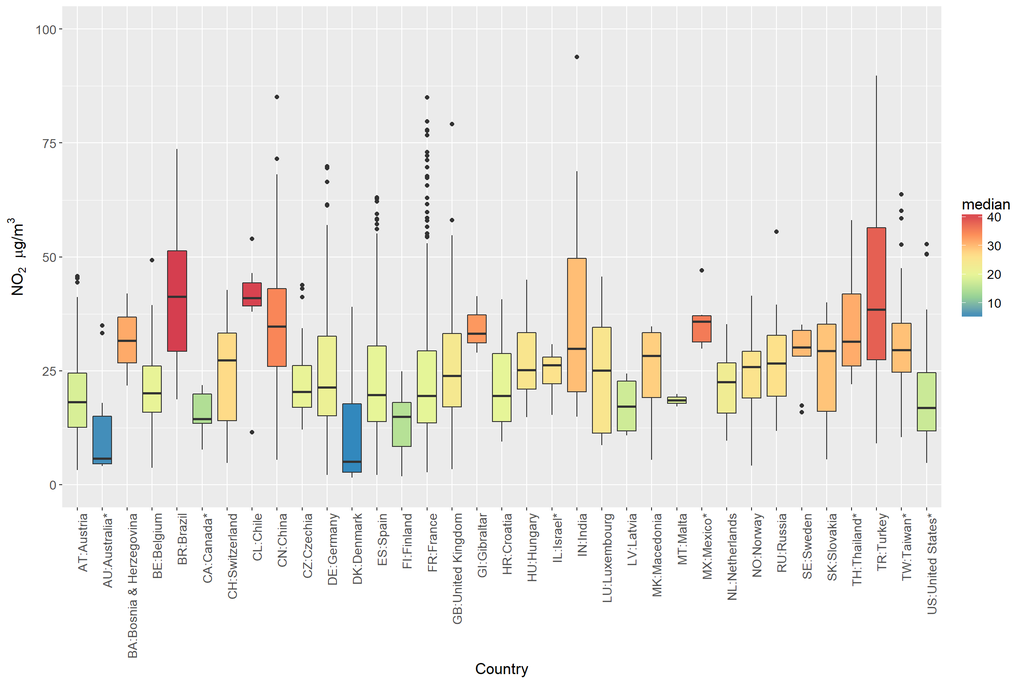

```r
countryname =   paste(merged_mr$country, countrycode(merged_mr$country, 'iso2c', 'country.name'), sep = ":")

#tag country with ppm
countryname_s_e=ifelse( merged_mr$country%in%countrywithppm[countrywithppm%in%merged_mr$country], paste(countryname,"*", sep = ""), countryname)
merged_mr$countryfullname = countryname_s_e

# use the median for colour
mergedmedian = merged_mr%>%group_by(country)%>% mutate(median =  median(value_mean, na.rm = TRUE))


bp2 <- ggplot(mergedmedian, aes(x=countryfullname, y=value_mean, group=country)) +  labs(x = "Country", y = expression(paste("NO"[2],"  " , mu,"g/","m"^3)), cex = 1.5)+
  geom_boxplot(aes(fill =median))+theme(text = element_text(size=13), axis.text.x = element_text(angle = 90, hjust = 1)) +scale_fill_distiller(palette = "Spectral")
#   scale_color_brewer(direction = 1)
print( bp2+ ylim(0, 100))
```

Plot the paired correlation, for road predictors, population, Tropomi. For DE, CN, and world

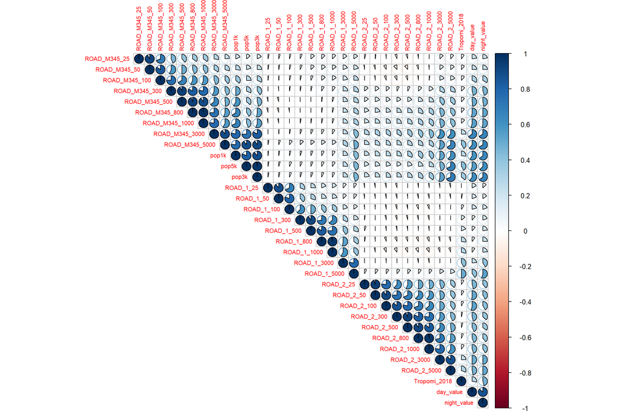

```r
 library(dplyr)
 merged_mr%>%na.omit%>%filter(country=="DE")%>%dplyr::select(matches("_value|ROAD|pop|Trop"))%>%cor%>%corrplot(type = "upper", method = "pie", tl.cex = 0.7)
```

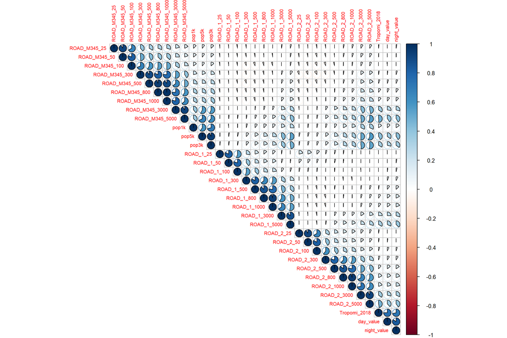

```r
 merged_mr%>%na.omit%>%filter(country=="CN")%>%dplyr::select(matches("_value|ROAD|pop|Trop"))%>%cor%>%corrplot(type = "upper", method = "pie", tl.cex = 0.7)
```

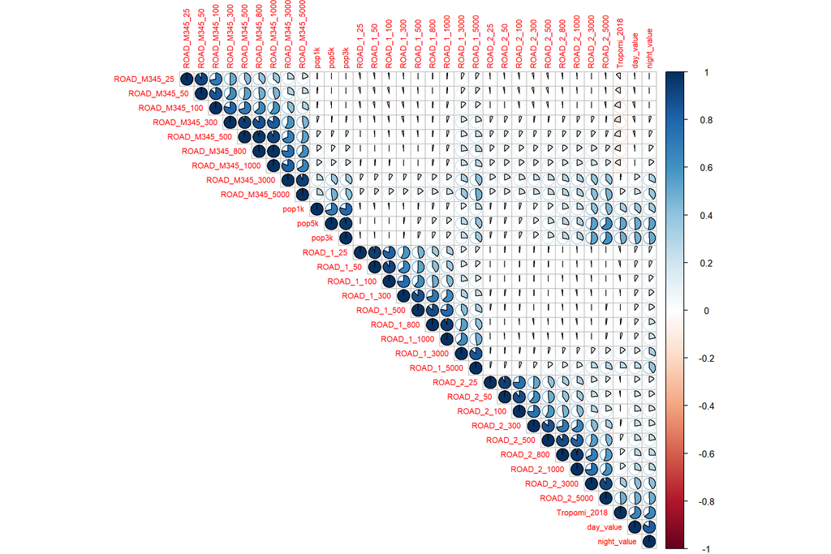

```r
 merged_mr%>%na.omit%>%dplyr::select(matches("_value|ROAD|pop|Trop"))%>%cor%>%corrplot(type = "upper", method = "pie", tl.cex = 0.7)
```

```r
#corrplot(cor(s),type = "upper", method ="ellipse", tl.cex= 0.5)
```

Spatial dependency

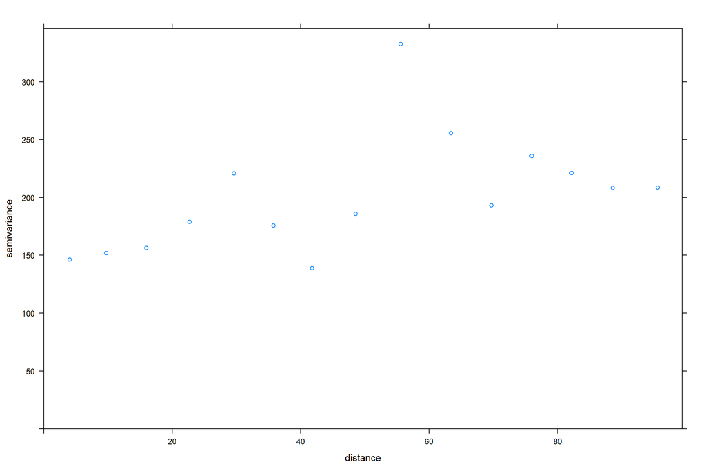

```r
library(gstat)
grd_sp <- as_Spatial(locations_sf)
dt.vgm = variogram(value_mean~1,grd_sp)
plot(dt.vgm)
```

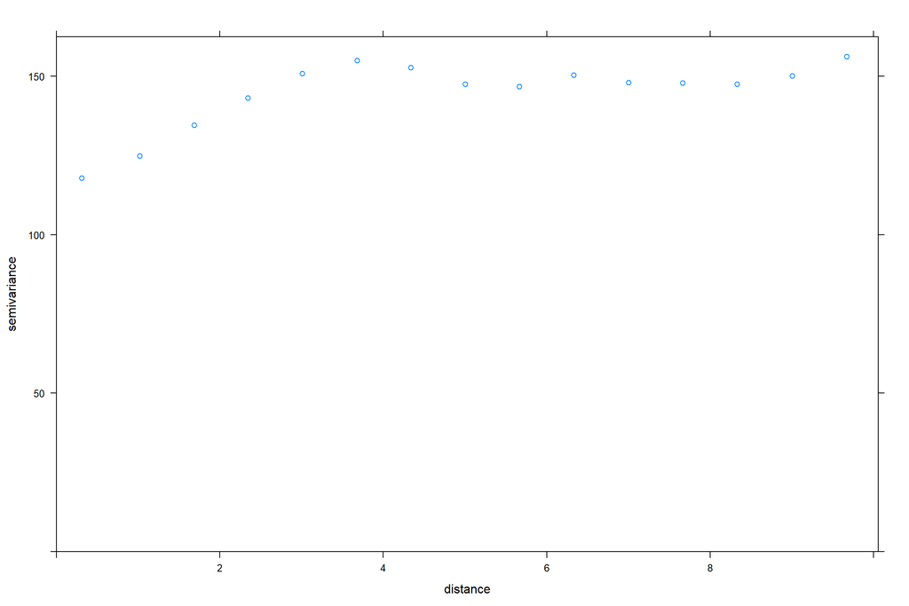

```r
dt.vgm = variogram(value_mean~1,grd_sp, cutoff = 10)
plot(dt.vgm)
```

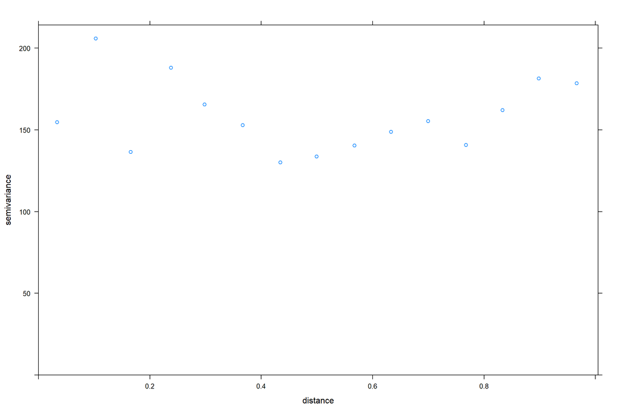

```r
countryvariogram = function(COUN, cutoff){
loca =  locations_sf%>%filter(country ==COUN)
grd_sp <- as_Spatial(loca)

dt.vgm = variogram(value_mean~1,grd_sp, cutoff = cutoff)
plot(dt.vgm)
}
#countryvariogram("DE")
countryvariogram("DE", 1)
```

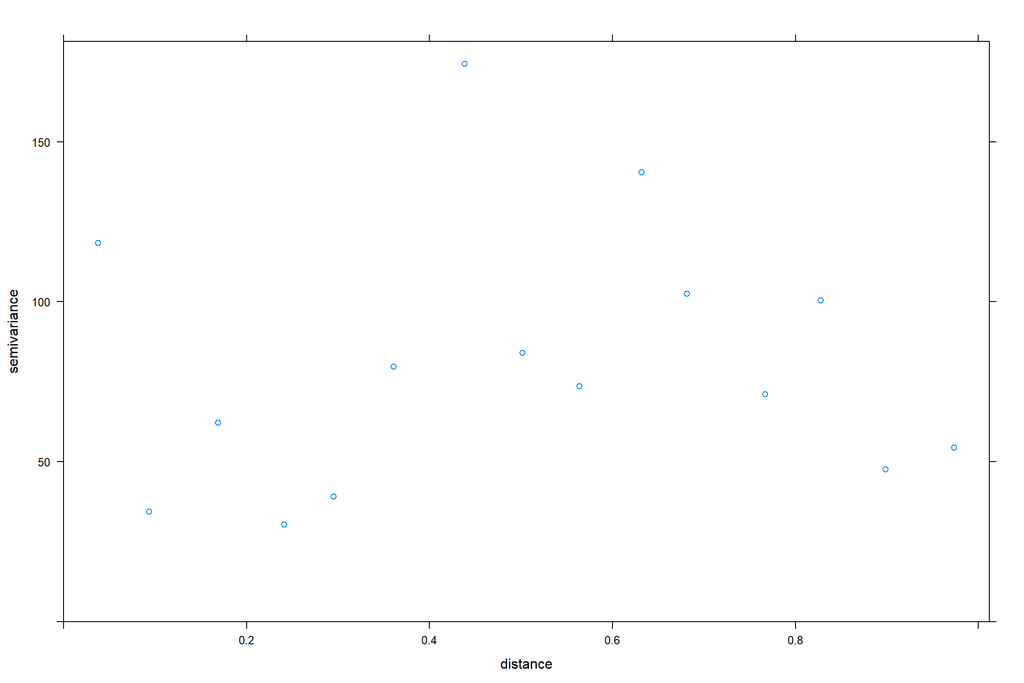

```r
countryvariogram("US", 1)
```

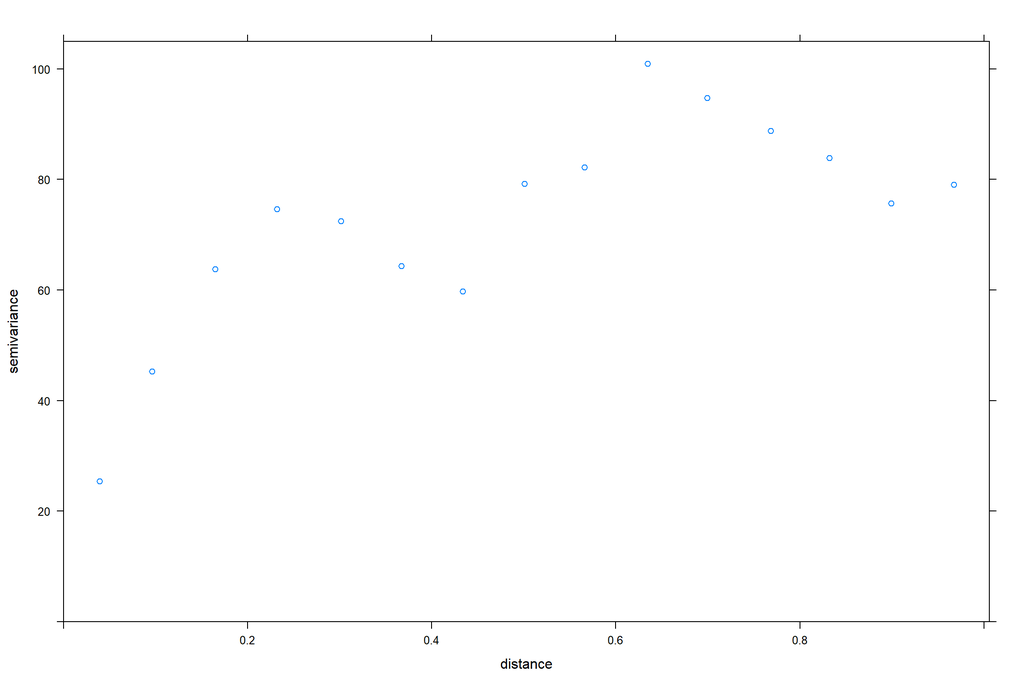

```r
countryvariogram("CN", 1)
```

```r
#countryvariogram("CN")



#Moran I test
#install.packages("ape", dependencies = TRUE)
#library(ape)

#merged_mrf =  merged_mr%>%filter(country == "US")
#no2.dists <- as.matrix(dist(cbind(merged_mrf$LONGITUDE, merged_mrf$LATITUDE)))
#no2.dists[1:5, 1:5]
#no2.inv <- 1/no2.dists
#diag(no2.inv) <- 0
#no2.inv[1:5, 1:5]
#Moran.I(merged_mrf$value_mean, na.rm = T, no2.inv)
```

spatial correlation of errors of random forest

```r
set.seed(2)
pr =  globalLUR::sampledf(merged_mr,fraction = 0.8, country2digit = "CN" ,grepstring_rm = "ID|countryfullname")
inde_var_train = with(pr, inde_var[training,])
inde_var_test = with(pr, inde_var[test,])
pre_mat = subset_grep(inde_var_train, grepstring = "ROAD|pop|value_mean|temp|wind|eleva|coast|I_1|Trop")
rf = ranger(value_mean~ ., data = pre_mat, mtry = 33, num.trees = 2000,importance = "permutation")
rf
```

```
## Ranger result
##
## Call:
##  ranger(value_mean ~ ., data = pre_mat, mtry = 33, num.trees = 2000,      importance = "permutation")
##
## Type:                             Regression
## Number of trees:                  2000
## Sample size:                      1009
## Number of independent variables:  65
## Mtry:                             33
## Target node size:                 5
## Variable importance mode:         permutation
## Splitrule:                        variance
## OOB prediction error (MSE):       36.68172
## R squared (OOB):                  0.7499481
```

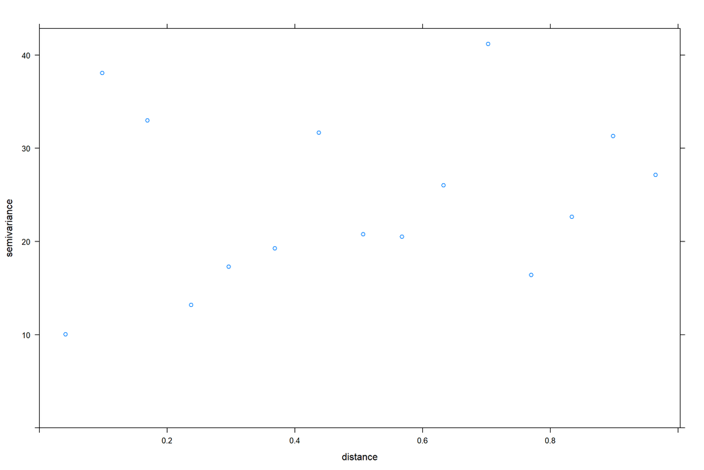

```r
errordf = with(inde_var_test, data.frame( error=predictions(predict(rf,inde_var_test)) -value_mean, LONGITUDE = LONGITUDE, LATITUDE = LATITUDE))

error_sp = errordf %>% st_as_sf(coords = c("LONGITUDE","LATITUDE")) %>% as_Spatial
dt.vgm = variogram(error~1,error_sp, cutoff = 1)
plot(dt.vgm)
```

### Data preprocessing:

0. add variables by ID or by rasters (not in this document).
1. remove unwanted columns or records,
2. select records (e.g. by country), separate testing and training sets.

Separate the dataset into training and test dataset with a fraction (her 80% of the records are used for training, the rest for testing), “DE” is the two digit for germany. If for world, the sampling uses the fraction per country.

```r
#merged = merge(merged, stat[,-which(names(stat)%in%c("LATITUTE", "LONGITUDE"))], by = "ID", all.x = T)
```

#### Germany as an example

```r
response_predictor= globalLUR::sampledf(merged_mr,fraction = 0.8, country2digit = "DE" ,grepstring_rm = "ID|LATITUDE|LONGITUDE|countryfullname")
```

Retrieve test, training, and all variables.

```r
test = response_predictor$test
training = response_predictor$training
inde_var = response_predictor$inde_var
inde_var = inde_var%>%dplyr::select(-country)
#summary(inde_var)
```

The size of test and training dataset

```r
length(test)
```

```
## [1] 67
```

```r
length(training)
```

```
## [1] 267
```

```r
#Checkt uni-variant R square. Caculate the r-sq for day, night and mean, and bind the columns to form a dataframe for plotting.

rsqmean = univar_rsq(inde_var[,-which(grepl("value_mean|day_|night_",names(inde_var)))],inde_var$value_mean)

rsqday = univar_rsq(inde_var[,-which(grepl("value_mean|day_|night_",names(inde_var)))],inde_var$day_value)

rsqnight = univar_rsq(inde_var[,-which(grepl("value_mean|day_|night_",names(inde_var)))],inde_var$night_value)

rsqdf= cbind(rsqmean,rsqday,rsqnight, rownames(rsqmean))
names(rsqdf)= c("mean","day","night","vars")

plot_rsq(rsqdf = rsqdf, varname = "vars",xlab = "predictors", ylab = "R-squared")
```

[output not shown]

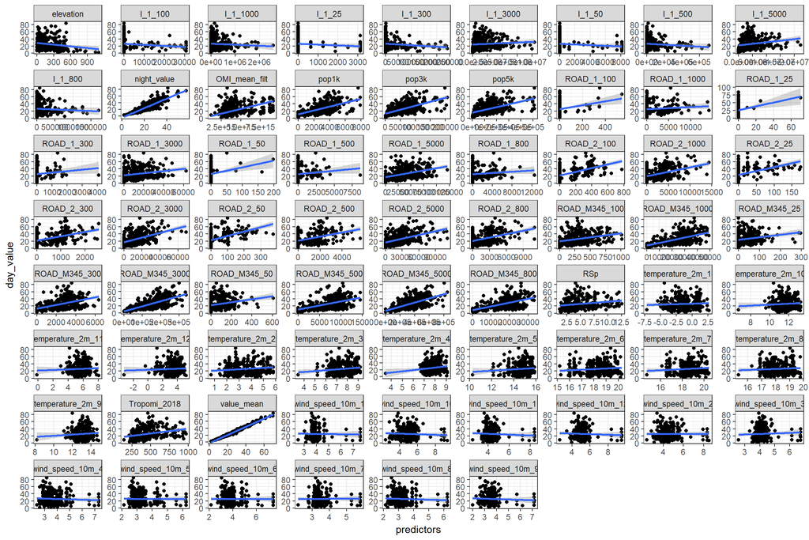

```r
#pre_mat = inde_var_train[,which(grepl("ROAD|pop|value_mean|day_value|night_value|temp|wind|Rsp|OMI|eleva|coast|I_1", names(inde_var_train)))]


#scatterplot(inde_var,"value_mean", "gam" )
scatterplot(inde_var,"day_value", "gam")
```

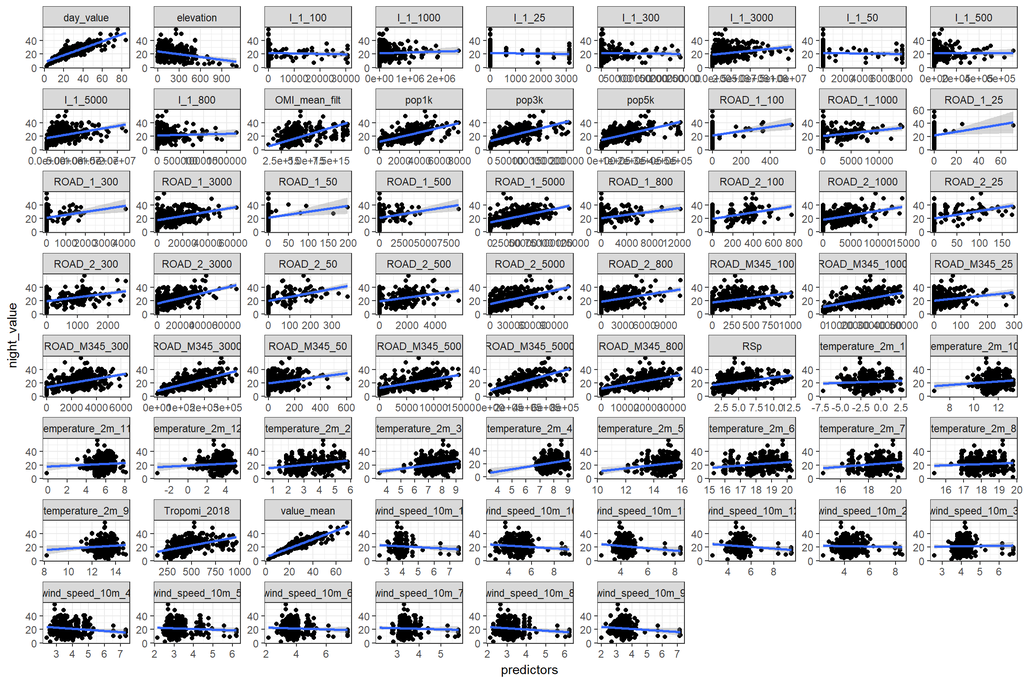

```r
scatterplot(inde_var,"night_value", "gam")
```

### Modelling

1. Tree based
2. Lasso
3. Mechanical model (nls)

Extra: 5) Separate urban/rural hirachical/ two-step linear regression 6) mixed effects regression

##### LM: linear regression model

If simply using linear regression, the mean, day, night. Predictors are population, temperature, wind speed, GEOM product, OMI tropo column, elevation, and road buffers.

i.e. ROAD|population|value_mean|temperature|wind|GEOM product|OMI|elevation.

###### Regression tree

The tree and prediction error will be different if shuffeling training and testing data.

```r
for (i in 2:5)
{set.seed(i)
testtree = globalLUR::sampledf(merged_mr,fraction = 0.8, "DE" )

with (testtree, ctree_LUR(inde_var, y_varname= c("day_value"), training= training, test=  test, grepstring ="ROAD|pop|temp|wind|Rsp|OMI|eleva|coast|I_1|Tropomi" ))
}
```

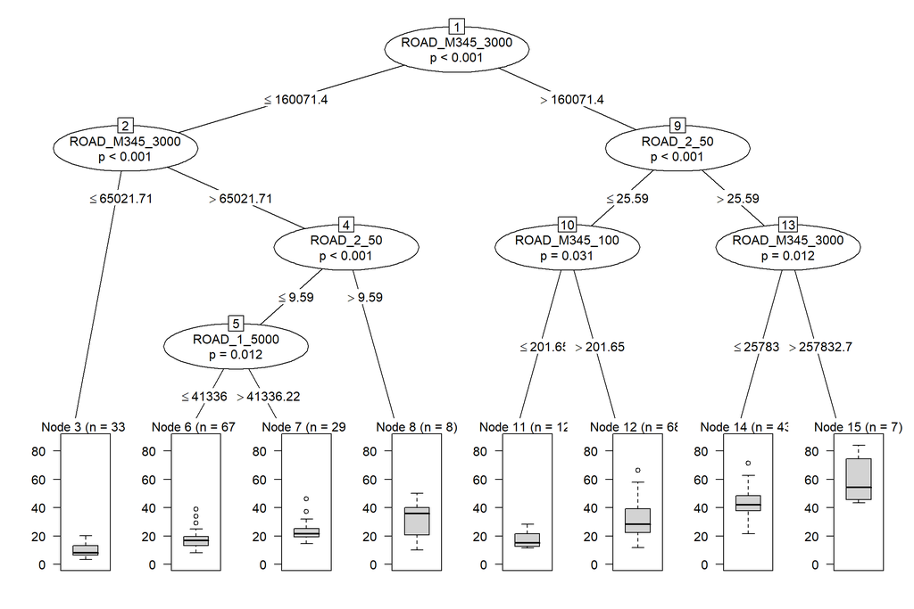

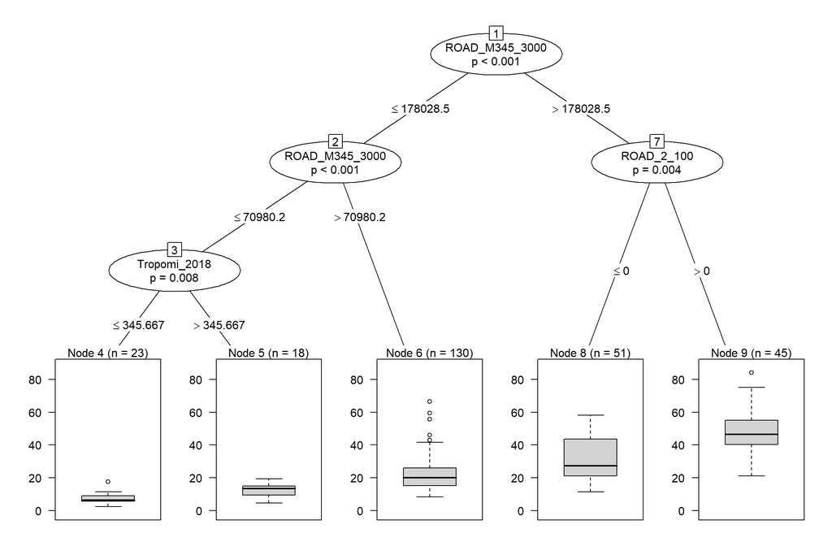

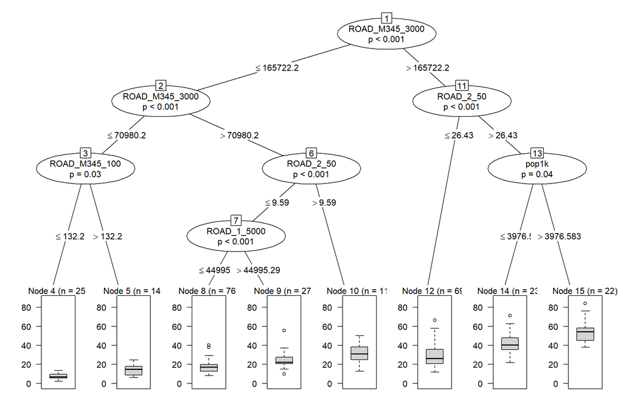

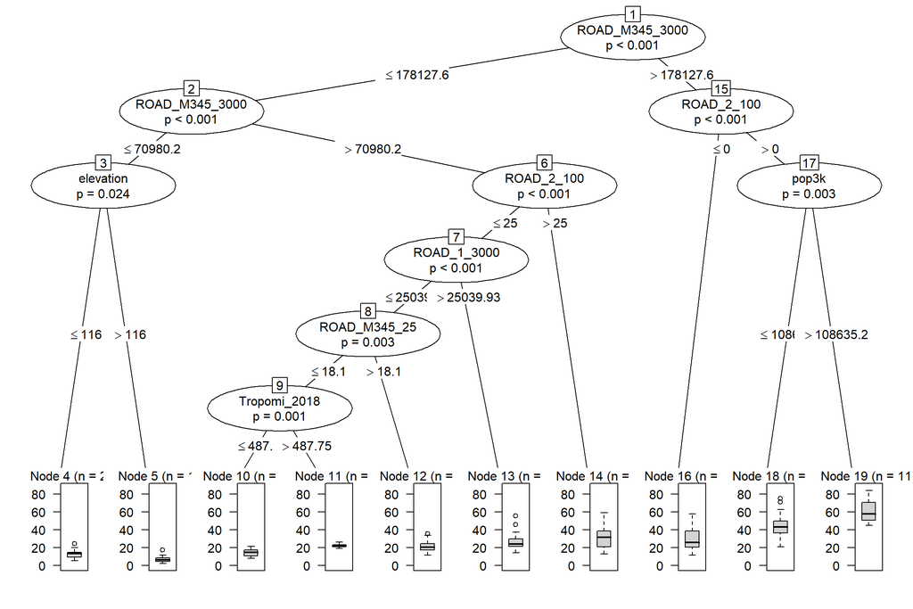

Creates diverse set of trees because 1) trees are instable w.r.t. changes in learning/training data (bagging) 2) randomly preselect mtry splitting variables in each split

model training and parameter tuning

```r
#caret
names(getModelInfo())
```

```
##   [1] "ada"                 "AdaBag"              "AdaBoost.M1"
##   [4] "adaboost"            "amdai"               "ANFIS"
##   [7] "avNNet"              "awnb"                "awtan"
##  [10] "bag"                 "bagEarth"            "bagEarthGCV"
##  [13] "bagFDA"              "bagFDAGCV"           "bam"
##  [16] "bartMachine"         "bayesglm"            "binda"
##  [19] "blackboost"          "blasso"              "blassoAveraged"
##  [22] "bridge"              "brnn"                "BstLm"
##  [25] "bstSm"               "bstTree"             "C5.0"
##  [28] "C5.0Cost"            "C5.0Rules"           "C5.0Tree"
##  [31] "cforest"             "chaid"               "CSimca"
##  [34] "ctree"               "ctree2"              "cubist"
##  [37] "dda"                 "deepboost"           "DENFIS"
##  [40] "dnn"                 "dwdLinear"           "dwdPoly"
##  [43] "dwdRadial"           "earth"               "elm"
```

[output cut: 65 more lines]

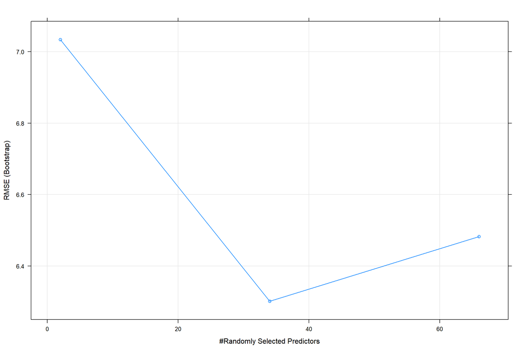

```r
inde_var_train= subset_grep(inde_var_train,"ROAD|pop|temp|wind|Rsp|OMI|eleva|coast|I_1|Tropomi|value_mean")
model_rf= train(value_mean ~ ., data=inde_var_train, method='rf') # mtry
plot(model_rf)
```

```r
fitted <- predict(model_rf, inde_var_test)
error_matrix(prediction = fitted, validation = inde_var_test$value_mean)
```

```
##     RMSE      MAE      IQR
## 5.882257 4.643824 7.844924
```

```r
#model_gbm= train(value_mean ~ ., data=inde_var_train, method='gbm')
#plot(model_gbm)
#gbm.step optimal number of trees.
```

```r
#install.packages("caretEnsemble")
library(caretEnsemble)

# Stacking Algorithms - Run multiple algos in one call.
trainControl <- trainControl(method="repeatedcv",
                             number=10,
                             repeats=2,
                             savePredictions=TRUE,
                             classProbs=TRUE)

algorithmList <- c('rf', 'adaboost', 'earth', 'xgbDART', 'svmRadial')

set.seed(100)
models <- caretList(value_mean ~ ., data=inde_var_train, trControl=trainControl, methodList=algorithmList)
results <- resamples(models)
summary(results)
```

#### Important variables and Partial plots: using the “vip” package

```r
vip::list_metrics()
```

```
##     Metric                       Description                      Task
## 1      auc            Area under (ROC) curve     Binary classification
## 2    error           Misclassification error     Binary classification
## 3  logloss                          Log loss     Binary classification
## 4     mauc Multiclass area under (ROC) curve Multiclass classification
## 5 mlogloss               Multiclass log loss Multiclass classification
## 6      mse                Mean squared error                Regression
## 7       r2                         R squared                Regression
## 8 rsquared                         R squared                Regression
## 9     rmse           Root mean squared error                Regression
```

```r
pre_mat = subset_grep(inde_var_train, grepstring = "ROAD|pop|value_mean|temp|wind|eleva|coast|I_1|Trop")
rf = ranger(value_mean~ ., data = pre_mat, mtry = 33, num.trees = 2000,importance = "permutation")
rf
```

```
## Ranger result
##
## Call:
##  ranger(value_mean ~ ., data = pre_mat, mtry = 33, num.trees = 2000,      importance = "permutation")
##
## Type:                             Regression
## Number of trees:                  2000
## Sample size:                      1009
## Number of independent variables:  65
## Mtry:                             33
## Target node size:                 5
## Variable importance mode:         permutation
## Splitrule:                        variance
## OOB prediction error (MSE):       36.56284
## R squared (OOB):                  0.7507585
```

```r
# ranger method
importance(rf)
```

```
##      ROAD_M345_25      ROAD_M345_50     ROAD_M345_100     ROAD_M345_300
##      3.074927e-01      8.138441e-02      1.339113e-01      4.585887e-01
##     ROAD_M345_500     ROAD_M345_800    ROAD_M345_1000    ROAD_M345_3000
##      9.017646e-01      1.130959e+00      1.048356e+00      1.647554e+00
##    ROAD_M345_5000         elevation             pop1k  temperature_2m_1
##      4.936975e+00      1.852660e+00      7.042597e-01      1.068113e+01
## temperature_2m_10 temperature_2m_11 temperature_2m_12  temperature_2m_2
##      3.853543e+00      2.830166e+00      4.450352e+00      8.972359e+00
##  temperature_2m_3  temperature_2m_4  temperature_2m_5  temperature_2m_6
##      2.632878e+00      2.128695e+00      4.192356e+00      2.236645e+00
##  temperature_2m_7  temperature_2m_8  temperature_2m_9  wind_speed_10m_1
##      2.532986e+00      2.246415e+00      3.545192e+00      2.456641e+00
## wind_speed_10m_10 wind_speed_10m_11 wind_speed_10m_12  wind_speed_10m_2
##      3.929006e+00      3.593019e+00      1.996955e+00      3.790343e+00
##  wind_speed_10m_3  wind_speed_10m_4  wind_speed_10m_5  wind_speed_10m_6
##      2.389524e+00      3.145545e+00      2.196837e+00      9.775329e-01
##  wind_speed_10m_7  wind_speed_10m_8  wind_speed_10m_9             pop5k
##      2.083690e+00      3.791864e+00      1.828274e+00      2.975476e+00
##             pop3k         ROAD_1_25         ROAD_1_50        ROAD_1_100
##      1.339326e+00      9.515012e-04      2.679628e-03      2.454653e-02
##        ROAD_1_300        ROAD_1_500        ROAD_1_800       ROAD_1_1000
##      1.169003e-01      3.238889e-01      6.718495e-01      3.029119e-01
##       ROAD_1_3000       ROAD_1_5000         ROAD_2_25         ROAD_2_50
##      2.071971e+00      3.162235e+00      5.091910e-04      1.328243e-02
##        ROAD_2_100        ROAD_2_300        ROAD_2_500        ROAD_2_800
##      2.109078e-03      9.427767e-03      7.175731e-02      2.787653e-01
##       ROAD_2_1000       ROAD_2_3000       ROAD_2_5000            I_1_25
##      2.060113e-01      1.035923e+00      1.991290e+00     -9.245193e-03
##            I_1_50           I_1_100           I_1_300           I_1_500
##     -5.621332e-03     -1.565699e-02      9.497315e-03     -1.179186e-02
##           I_1_800          I_1_1000          I_1_3000          I_1_5000
##      3.860088e-02      1.041510e-01      1.164940e+00      1.754118e+00
##      Tropomi_2018
##      1.349233e+02
```

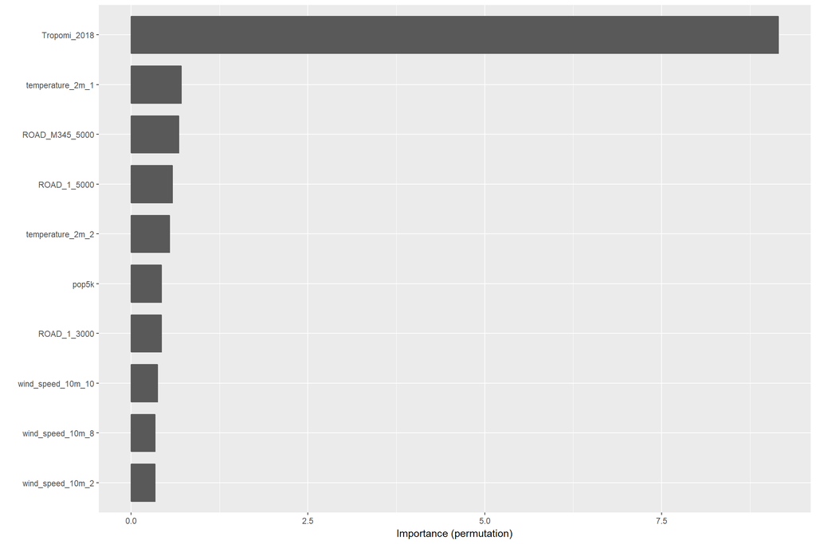

```r
#vip
DF_P_r2 = vi(rf, method = "permute", target = "value_mean", metric = "r2" )
DF_P_rmse = vi(rf, method = "permute", target = "value_mean", metric = "rmse")

vip (DF_P_rmse)
```

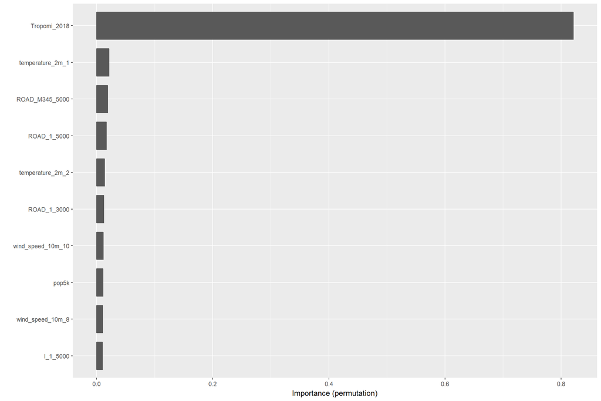

```r
vip (DF_P_r2)
```

partial dependence plots: all the variables. (using sparklines takes a while)

```r
library(DT)
library(sparkline)
a=add_sparklines(DF, fit = rf)
library(htmlwidgets)
saveWidget(a, file="sparkline.html")
```

Partial dependence plot of selected variables

```r
library(GGally)
pre_mat_s = inde_var_train%>%select(value_mean, ROAD_2_50, pop3k, ROAD_M345_300)


lm_s = lm(value_mean~., data = pre_mat_s)

rf_s = ranger(value_mean~ ., data = pre_mat_s, num.trees = 2000,importance = "permutation")
rf_s
```

```
## Ranger result
##
## Call:
##  ranger(value_mean ~ ., data = pre_mat_s, num.trees = 2000, importance = "permutation")
##
## Type:                             Regression
## Number of trees:                  2000
## Sample size:                      1009
## Number of independent variables:  3
## Mtry:                             1
## Target node size:                 5
## Variable importance mode:         permutation
## Splitrule:                        variance
## OOB prediction error (MSE):       132.3622
## R squared (OOB):                  0.09771361
```

correlation

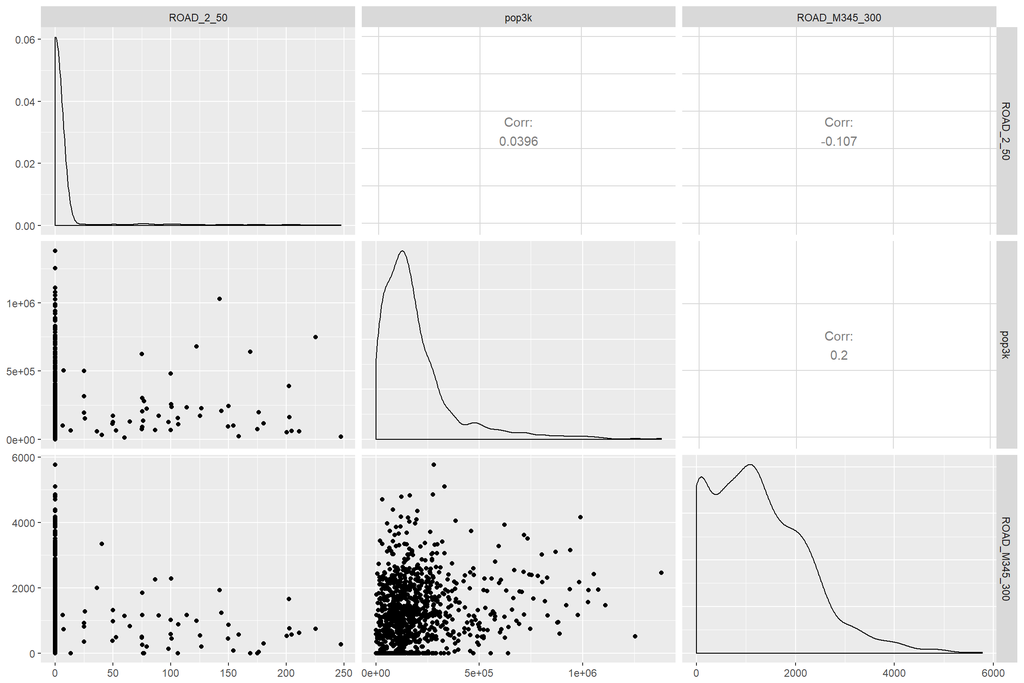

```r
pre_mat_predictor = pre_mat_s%>%select(-value_mean)
ggpairs(pre_mat_predictor)
```

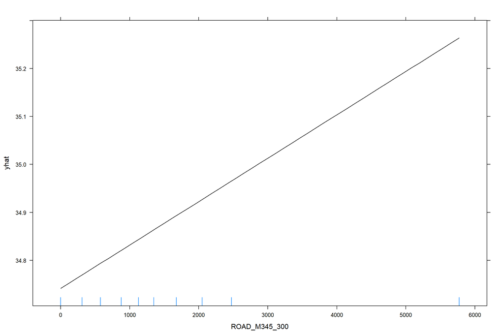

```r
p_lm=partial(lm_s, "ROAD_M345_300",plot = TRUE, rug = TRUE)
plot(p_lm)
```

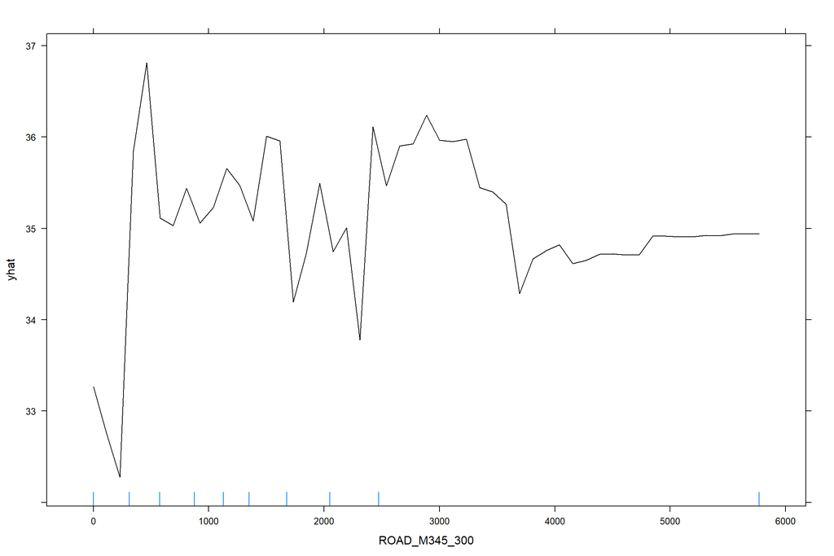

```r
p2=partial(rf_s, "ROAD_M345_300",plot = TRUE, rug = TRUE)
plot(p2)
```

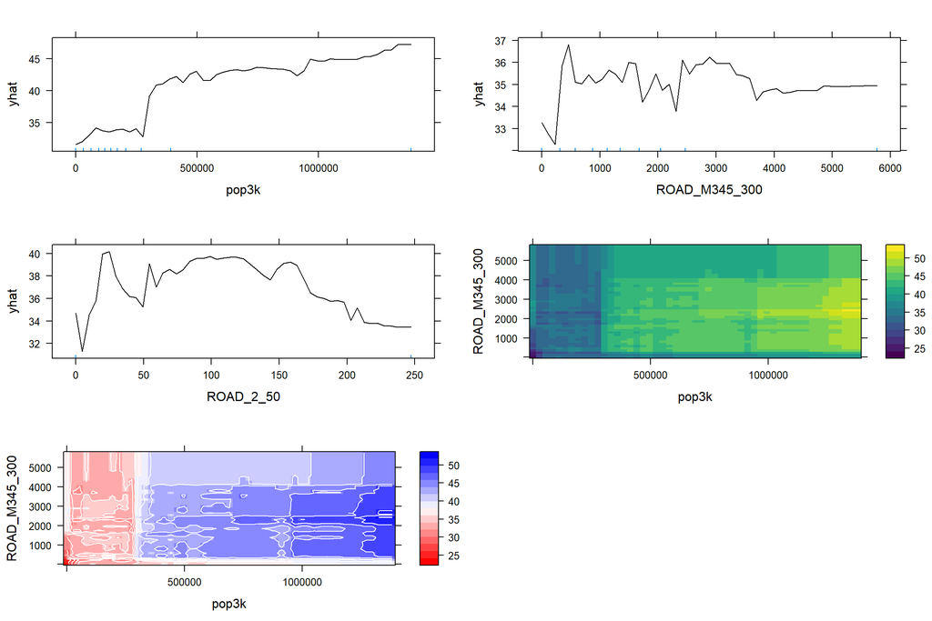

```r
#slow
pd <- partial(rf_s, pred.var = c("pop3k", "ROAD_M345_300"  ))

# Default PDP
pd1 = plotPartial(pd)

# Add contour lines and use a different color palette
rwb <- colorRampPalette(c("red", "white", "blue"))
pdp2= plotPartial(pd, contour = TRUE, col.regions = rwb)

# 3-D surface
#pdp3 <- plotPartial(pd, levelplot = F, zlab = "ROAD_1_50", colorkey = T,
#                   screen = list(z = -20, x = -60) )

p3= partial(rf_s, "ROAD_2_50",plot = TRUE, rug = TRUE)
p1 = partial(rf_s, "pop3k",plot = TRUE, rug = TRUE)
grid.arrange(p1, p2,p3, pd1, pdp2 , ncol = 2)
```

#### Gradient boosting

```r
gbm1 =  gbm(formula = value_mean~., data = pre_mat, distribution = "gaussian", n.trees = 2000,
  interaction.depth = 6, shrinkage = 0.01, bag.fraction = 0.5 )
names(pre_mat)
```

```
##  [1] "ROAD_M345_25"      "ROAD_M345_50"      "ROAD_M345_100"
##  [4] "ROAD_M345_300"     "ROAD_M345_500"     "ROAD_M345_800"
##  [7] "ROAD_M345_1000"    "ROAD_M345_3000"    "ROAD_M345_5000"
## [10] "value_mean"        "elevation"         "pop1k"
## [13] "temperature_2m_1"  "temperature_2m_10" "temperature_2m_11"
## [16] "temperature_2m_12" "temperature_2m_2"  "temperature_2m_3"
## [19] "temperature_2m_4"  "temperature_2m_5"  "temperature_2m_6"
## [22] "temperature_2m_7"  "temperature_2m_8"  "temperature_2m_9"
## [25] "wind_speed_10m_1"  "wind_speed_10m_10" "wind_speed_10m_11"
## [28] "wind_speed_10m_12" "wind_speed_10m_2"  "wind_speed_10m_3"
## [31] "wind_speed_10m_4"  "wind_speed_10m_5"  "wind_speed_10m_6"
## [34] "wind_speed_10m_7"  "wind_speed_10m_8"  "wind_speed_10m_9"
## [37] "pop5k"             "pop3k"             "ROAD_1_25"
## [40] "ROAD_1_50"         "ROAD_1_100"        "ROAD_1_300"
## [43] "ROAD_1_500"        "ROAD_1_800"        "ROAD_1_1000"
## [46] "ROAD_1_3000"       "ROAD_1_5000"       "ROAD_2_25"
## [49] "ROAD_2_50"         "ROAD_2_100"        "ROAD_2_300"
## [52] "ROAD_2_500"        "ROAD_2_800"        "ROAD_2_1000"
## [55] "ROAD_2_3000"       "ROAD_2_5000"       "I_1_25"
## [58] "I_1_50"            "I_1_100"           "I_1_300"
## [61] "I_1_500"           "I_1_800"           "I_1_1000"
## [64] "I_1_3000"          "I_1_5000"          "Tropomi_2018"
```

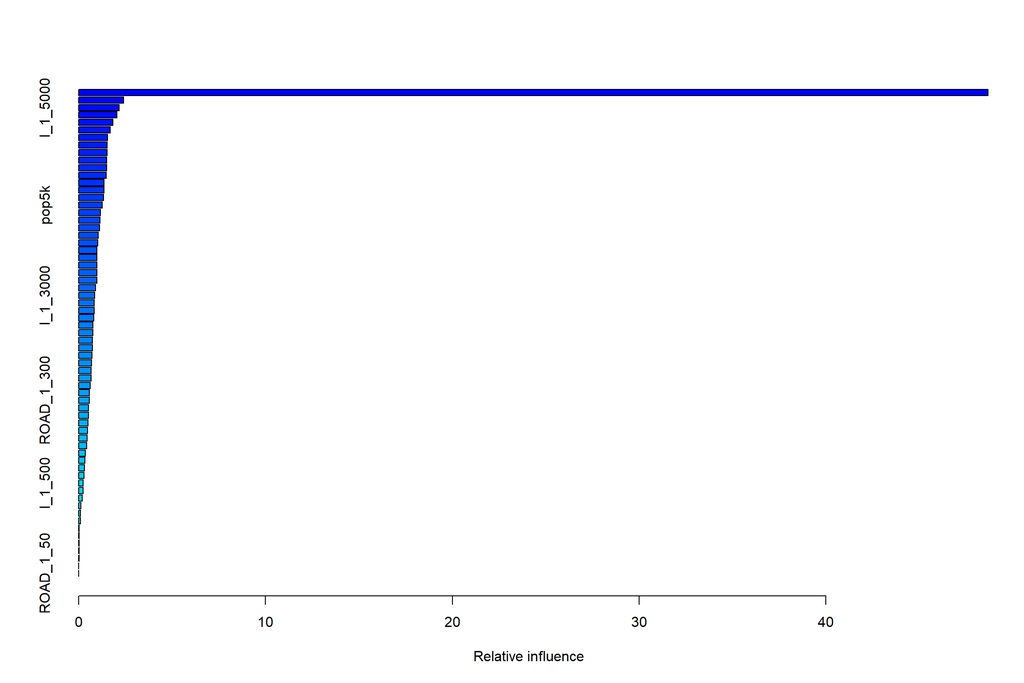

```
##                                 var      rel.inf
## Tropomi_2018           Tropomi_2018 48.695227450
## ROAD_1_5000             ROAD_1_5000  2.389021340
## I_1_5000                   I_1_5000  2.146167548
## temperature_2m_1   temperature_2m_1  2.038585885
## wind_speed_10m_10 wind_speed_10m_10  1.818920664
## wind_speed_10m_2   wind_speed_10m_2  1.674247512
## wind_speed_10m_11 wind_speed_10m_11  1.531130411
## ROAD_M345_3000       ROAD_M345_3000  1.523029985
## wind_speed_10m_8   wind_speed_10m_8  1.513719008
## pop1k                         pop1k  1.494025398
## ROAD_1_3000             ROAD_1_3000  1.483778865
## ROAD_M345_800         ROAD_M345_800  1.459282302
## pop3k                         pop3k  1.340032472
## elevation                 elevation  1.335769488
## ROAD_M345_5000       ROAD_M345_5000  1.318190921
## pop5k                         pop5k  1.244705829
## wind_speed_10m_3   wind_speed_10m_3  1.146555284
## ROAD_2_5000             ROAD_2_5000  1.128673936
## temperature_2m_10 temperature_2m_10  1.116029576
## temperature_2m_8   temperature_2m_8  1.048627295
## wind_speed_10m_12 wind_speed_10m_12  1.009237494
## temperature_2m_3   temperature_2m_3  0.976271312
## temperature_2m_9   temperature_2m_9  0.970917956
## wind_speed_10m_7   wind_speed_10m_7  0.968956996
## wind_speed_10m_1   wind_speed_10m_1  0.963905276
## ROAD_2_3000             ROAD_2_3000  0.956991598
## ROAD_M345_1000       ROAD_M345_1000  0.905657461
## I_1_3000                   I_1_3000  0.845224872
## wind_speed_10m_5   wind_speed_10m_5  0.833934621
## temperature_2m_11 temperature_2m_11  0.816582954
## temperature_2m_7   temperature_2m_7  0.801859151
## ROAD_M345_500         ROAD_M345_500  0.759415240
## wind_speed_10m_6   wind_speed_10m_6  0.742147054
## wind_speed_10m_4   wind_speed_10m_4  0.737317362
## temperature_2m_12 temperature_2m_12  0.725566692
## temperature_2m_5   temperature_2m_5  0.713006435
## temperature_2m_6   temperature_2m_6  0.677850817
## ROAD_1_500               ROAD_1_500  0.654153224
## ROAD_1_800               ROAD_1_800  0.652491540
```

[output cut: 11 more lines]

```
## ROAD_1_1000             ROAD_1_1000  0.296697610
## ROAD_M345_50           ROAD_M345_50  0.283911109
## I_1_500                     I_1_500  0.232764449
## ROAD_M345_25           ROAD_M345_25  0.223556319
## I_1_800                     I_1_800  0.187510990
## ROAD_1_100               ROAD_1_100  0.115894881
## ROAD_2_100               ROAD_2_100  0.080958415
## I_1_300                     I_1_300  0.075857386
## ROAD_2_25                 ROAD_2_25  0.019802459
## I_1_100                     I_1_100  0.017444185
## I_1_50                       I_1_50  0.011743392
## ROAD_2_50                 ROAD_2_50  0.004418914
## I_1_25                       I_1_25  0.003304016
## ROAD_1_25                 ROAD_1_25  0.000000000
## ROAD_1_50                 ROAD_1_50  0.000000000
```

```r
summary(gbm1)
```

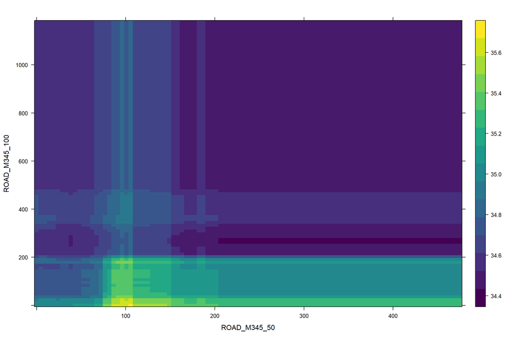

```r
plot(gbm1, i.var = 2:3)
```

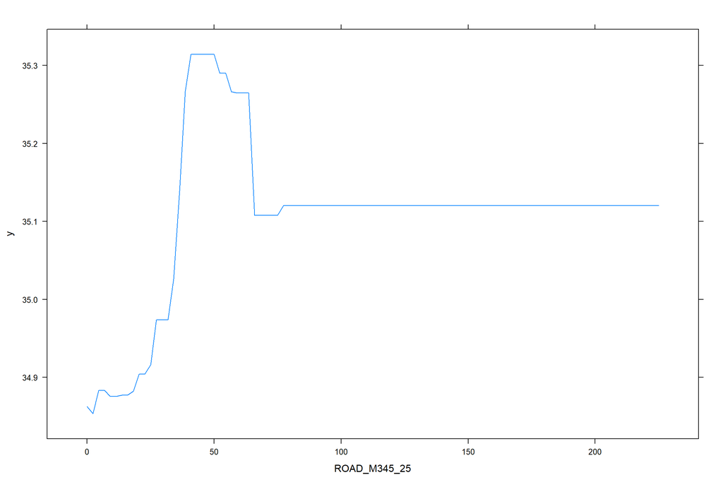

```r
plot(gbm1, i.var = 1)
```

```r
#rf_residual <- pre_rf -  rdf_test$NO2
```

Xgboost

```r
varstring = "ROAD|pop|temp|wind|RSp|OMI|eleva|coast|I_1|Tropo"
xgboost_LUR(inde_var, max_depth =4, eta =0.02, nthread =2, nrounds = 2000, y_varname= c("day_value"),training=training, test=test, grepstring =varstring )
```

```
##            Feature        Gain       Cover   Frequency
##  1:      ROAD_2_50 0.292697003 0.027536081 0.015764008
##  2: ROAD_M345_3000 0.231099495 0.024278182 0.022735550
##  3:   Tropomi_2018 0.054120691 0.017375303 0.018989647
##  4:   ROAD_M345_25 0.052507074 0.043964660 0.120753343
##  5:    ROAD_1_5000 0.041820089 0.028449801 0.028718589
##  6:          pop1k 0.040587611 0.019763800 0.021747048
##  7:          pop3k 0.033021236 0.010700618 0.008896519
##  8: ROAD_M345_5000 0.032848168 0.049010396 0.039748192
##  9:  ROAD_M345_300 0.031693307 0.043923170 0.051818324
## 10:       I_1_1000 0.022601167 0.038478566 0.030487488
## 11:     ROAD_2_100 0.011839472 0.015215943 0.009676916
## 12:          pop5k 0.009794004 0.031629906 0.020810572
## 13: ROAD_M345_1000 0.008558799 0.022682236 0.023203788
## 14:      ROAD_1_50 0.008272075 0.004868932 0.002445242
## 15:    ROAD_2_3000 0.008030678 0.023962765 0.027574008
```

```
##      RMSE       MAE       IQR
## 11.743413  8.744169 11.891272
```

```r
xgboost_imp (variabledf= inde_var, y_varname= "day_value", max_depth =5, eta =0.02, nthread =4, nrounds = 2000, training=training, test=test, grepstring =varstring )
```

```
##                        imp_val
## elevation         3.004744e-03
## I_1_100           9.114986e-05
## I_1_1000          1.182291e-02
## I_1_25            1.570901e-05
## I_1_300           1.634391e-03
## I_1_3000          6.525441e-03
## I_1_50            6.896480e-05
## I_1_500           2.704183e-03
## I_1_5000          6.345658e-03
## I_1_800           3.028298e-03
## OMI_mean_filt     1.948323e-03
## pop1k             5.353444e-02
## pop3k             3.103482e-02
## pop5k             6.796109e-03
## ROAD_1_100        4.743487e-03
## ROAD_1_1000       9.781715e-04
## ROAD_1_25         6.115180e-03
## ROAD_1_300        1.074919e-04
## ROAD_1_3000       5.089307e-03
## ROAD_1_50         7.009847e-03
## ROAD_1_500        1.086247e-05
## ROAD_1_5000       3.484051e-02
## ROAD_1_800        1.948362e-03
## ROAD_2_100        1.468802e-02
## ROAD_2_1000       4.000886e-03
## ROAD_2_25         7.587811e-04
## ROAD_2_300        5.444651e-03
## ROAD_2_3000       7.813149e-03
## ROAD_2_50         2.049027e-01
## ROAD_2_500        1.172282e-03
## ROAD_2_5000       3.679915e-03
## ROAD_2_800        5.159414e-03
## ROAD_M345_100     5.705411e-03
## ROAD_M345_1000    6.579631e-03
## ROAD_M345_25      6.019957e-02
## ROAD_M345_300     2.826323e-02
## ROAD_M345_3000    3.637991e-01
## ROAD_M345_50      3.666224e-03
## ROAD_M345_500     3.104294e-03
```

[output cut: 13 more lines]

```
## temperature_2m_8  7.086377e-04
## temperature_2m_9  6.261099e-04
## Tropomi_2018      3.045498e-02
## wind_speed_10m_1  3.518145e-04
## wind_speed_10m_10 4.666575e-04
## wind_speed_10m_11 8.550586e-04
## wind_speed_10m_12 1.424584e-04
## wind_speed_10m_2  3.195698e-04
## wind_speed_10m_3  3.505000e-03
## wind_speed_10m_4  4.221565e-04
## wind_speed_10m_5  9.662377e-03
## wind_speed_10m_6  5.140037e-05
## wind_speed_10m_7  8.460361e-03
## wind_speed_10m_8  2.305083e-06
## wind_speed_10m_9  4.024605e-03
```